# Predictive Fleet Rebalancing: A Data Science Study of Spatial Imbalance in NYC Citi Bike (September 2024)

Antigravity Data Science Pair Programming Team

2026-11-06

# 1 Problem Statement & Objectives

Bike-sharing systems have emerged as an indispensable backbone of modern urban transit, delivering flexible, zero-emission, first-and-last-mile connectivity across metropolitan centers. However, their operational efficiency is perpetually challenged by **tidal spatio-temporal demand asymmetry**. During morning rush hours, hundreds of thousands of commuters unlock bicycles from residential outer-borough neighborhoods and ride inward toward employment hubs in Midtown and Lower Manhattan. By evening, this directional flow reverses.

This structural asymmetry rapidly empties residential docking stations (leaving aspiring riders with no bikes) and overwhelms commercial stations (leaving arriving commuters unable to dock). To mitigate these failures, system operators deploy fleets of vans and trucks to physically rebalance bicycles between full and empty stations.

```
       [ Residential Neighborhoods ]              [ Commercial Business District ]
                (Origins)                                   (Destinations)
                    |                                             |
   Morning Commute: | == Outbound Trip Depletion ===============> | == Inbound Dock Congestion
                    |                                             |
   Rebalancing:     | <== Mobile Van Replenishment ============== | <== Truck Corral Clearance
                    |                                             |
   Evening Commute: | <== Inbound Trip Return =================== | <== Outbound Departure Surge
```

### 1.0.1 Core Research Objectives

This investigation develops an end-to-end data science framework to study, model, and predict station inventory stress across the entire New York City Citi Bike network throughout September 2024:

1. **Quantify Network-Wide Inventory Imbalance**: Define a discrete 2-hour net-flow target metric ($\Delta = \text{arrivals} - \text{departures}$) across active stations to identify acute depletion (“Drainers”, $\Delta \le -5$) and dock saturation (“Collectors”, $\Delta \ge 5$).
2. **Evaluate Transit Multimodality**: Measure the spatial walking-shed proximity between Citi Bike stations and Metropolitan Transportation Authority (MTA) subway entrances in projected metric coordinates (EPSG:32618 UTM Zone 18N).
3. **Discover Spatial Corridors & Diurnal Typologies**: Identify dense linear transit corridors via density-based spatial clustering (DBSCAN) and categorize diurnal station operational personalities using 24-hour departure share Principal Component Analysis (PCA) and k-means clustering.
4. **Model Meteorological Elasticity**: Measure the non-linear relationship between hourly ridership and temperature, precipitation, wind speed, and humidity using overdispersed Negative Binomial generalized linear models (GLMs).
5. **Hold-Out Time-Series Forecasting**: Evaluate multi-step out-of-sample system demand forecasts across a 7-day held-out test horizon comparing Seasonal Naïve, STL+ETS (`stlf`), and Dynamic Harmonic Regression (ARIMA with Fourier terms).
6. **Machine Learning Imbalance Benchmark**: Compare 9 supervised machine learning classifiers alongside a naive baseline, applying rigorous chronological splitting, rolling cross-validation, and leak-free target encoding to predict proactive 2-hour rebalancing needs.

> **Operational Data Limitation Note**: Throughout this report, inventory stress is operationalized as **net-flow imbalance (arrivals minus departures in a 2-hour window)**. Citi Bike does not publish historical bike counts or dock occupancy per station over time, so true empty/full events cannot be observed directly from trip transaction logs.

# 2 Literature Review

The academic literature on shared micro-mobility systems spans inventory rebalancing optimization, spatial-temporal demand modeling, multimodal public transit synergy, and predictive machine learning. This study builds upon ten foundational works:

1. **DeMaio (2009)** provides the definitive historical overview of bike-sharing generations, highlighting how automated IT tracking transformed municipal bike-sharing from unregulated community experiments into formal public transit utilities, while establishing fleet rebalancing as the primary operational cost.
2. **Fishman (2016)** synthesizes international empirical findings on bikeshare ridership determinants, documenting how safety infrastructure, topography, and transit proximity drive adoption, while identifying dock availability as the primary determinant of user satisfaction.
3. **Raviv, Tzur, & Forma (2013)** formulate the static repositioning problem as a mixed-integer linear program (MILP) to compute expected penalty functions for unsatisfied demand, demonstrating that non-linear inventory penalty functions are critical for routing rebalancing vehicles.
4. **Schuijbroek, Hampshire, & van Hoeve (2017)** combine inventory service level bounds with the vehicle routing problem (VRP) across large-scale systems, establishing scalable cluster-first route-second heuristics for balancing multi-thousand station networks.
5. **O’Mahony & Shmoys (2015)** present a data-driven optimization framework deployed in partnership with Citi Bike NYC, demonstrating how historical trip clustering and integer programming drastically reduce commuter dock starvation in Manhattan.
6. **Vogel, Greiser, & Mattfeld (2011)** apply unsupervised data mining and k-means clustering to diurnal pickup and dropoff time-series in Vienna, proving that station activity signatures reflect localized land-use zoning and commuting corridors.
7. **Corcoran, Li, Rohde, Charles-Edwards, & Mateo-Babiano (2014)** analyze the sensitivity of public bicycle share programs to weather fluctuations and calendar events, demonstrating non-linear threshold effects where precipitation sharply curtails casual trips while commuter trips exhibit greater inelasticity.
8. **Faghih-Imani, Eluru, El-Geneidy, Rabbat, & Haq (2014)** examine the spatial determinants of bicycle flows in Montreal using destination choice models, confirming that proximity to metro stations, restaurant density, and dedicated cycle paths significantly boost station throughput.
9. **Austwick, O’Brien, Strano, & Viana (2013)** evaluate the complex network topology of bike-share systems across Europe and North America, showing that Citi Bike NYC exhibits dense core clustering surrounded by modular periphery branches.
10. **Ghosh, Varakantham, Adulyasak, & Jaillet (2017)** propose a dynamic repositioning mechanism under demand uncertainty that leverages spatio-temporal clustering and online vehicle routing to dynamically prevent dock-outs during rush hour peaks.

# 3 Datasets & Sources

The analytical pipeline synthesizes four authoritative open-data streams encompassing trip transactions, live station metadata, high-resolution hourly meteorology, and rapid transit infrastructure:

Summary of Integrated Data Sources

| Dataset Name | Provider / Source | Temporal Scope | Raw Rows | Attributes | License |
| --- | --- | --- | --- | --- | --- |
| Citi Bike Trips (NYC) | Citi Bike (Lyft Urban Solutions / S3 Bucket) | Sept 1 – Sept 30, 2024 | 4,997,898 | 13 columns | Citi Bike Data License |
| GBFS Station Metadata | Citi Bike GBFS Live Feed API | September 2024 Snapshot | 2,518 | 5 columns | GBFS Open Specification |
| Hourly Meteorology | Open-Meteo Historical Archive API | Sept 1 – Sept 30, 2024 (720 hrs) | 720 | 7 columns | CC BY 4.0 Open-Meteo |
| MTA Subway Entrances | MTA / New York State Open Data | Active NYC Infrastructure | 2,120 | 34 columns | NYS Open Data Terms |

### 3.0.1 Data Dictionary

The ingested datasets were harmonized into a centralized SQLite database (`data/citibike.sqlite`):

- **`trips` Table**: `ride_id` (UUID), `rideable_type` (classic / electric bike), `started_at` & `ended_at` (America/New_York timestamps), `start_station_id`, `start_station_name`, `start_lat`, `start_lng`, `end_station_id`, `end_station_name`, `end_lat`, `end_lng`, `member_casual` (annual member vs. casual user).
- **`stations` Table**: `station_id` (GBFS short identifier), `name`, `lat`, `lon`, `capacity` (physical dock count).
- **`weather` Table**: `time` (hourly timestamp), `temperature_2m` (°C), `precipitation` (mm), `wind_speed_10m` (km/h), `relative_humidity_2m` (%).
- **`subway` Table**: `station_name`, `line`, `latitude`, `longitude`, `entrance_type`.

### 3.0.2 Raw vs. Cleaned Counts

Raw Citi Bike trip logs contained **4,997,898** transactions across 5 monthly partition CSVs. After sequential quality validation, **4,708,761** valid trips were retained (94.21% retention rate).

# 4 Data Quality & Cleaning

Raw transactional logs from dock-based micro-mobility networks frequently contain noise resulting from GPS drift, aborted rides, maintenance transfers, and unrecorded docking events.

| step_number | step_description | rows_remaining | rows_dropped | pct_retained |
| --- | --- | --- | --- | --- |
| 0 | Raw Ingested Records | 4997898 | 0 | 100 |
| 1 | Parse Timestamps (America/New_York) | 4997898 | 0 | 100 |
| 2 | Drop Missing Coordinates and Station IDs | 4981399 | 16499 | 99.67 |
| 3 | Drop start &gt;= end | 4981399 | 0 | 99.67 |
| 4 | Drop Duration &lt;= 0 | 4981399 | 0 | 99.67 |
| 5 | Tukey IQR Duration Filter | 4708792 | 272607 | 94.22 |
| 6 | Compute Haversine Distance and Speed | 4708792 | 0 | 94.22 |
| 7 | Drop Speed &gt; 45 km/h | 4708761 | 31 | 94.21 |

Missing Value Audit on Raw Ingested Records

| column_name | missing_count | missing_pct | total_rows |
| --- | --- | --- | --- |
| ride_id | 0 | 0.0000 | 4997898 |
| rideable_type | 0 | 0.0000 | 4997898 |
| started_at | 0 | 0.0000 | 4997898 |
| ended_at | 0 | 0.0000 | 4997898 |
| start_station_name | 4460 | 0.0892 | 4997898 |
| start_station_id | 4460 | 0.0892 | 4997898 |
| end_station_name | 13835 | 0.2768 | 4997898 |
| end_station_id | 14439 | 0.2889 | 4997898 |

### 4.0.1 Mathematical Cleaning Formulations

1. **Tukey Interquartile Range (IQR) Duration Filter**: Let $Q_1$ and $Q_3$ represent the first and third quartiles of ride duration ($t$). The interquartile range is defined as:
   $$\text{IQR} = Q_3 - Q_1$$
   The permissible duration bounds are:
   $$t_{\text{min}} =
   \max\left(1.0,\, Q_1 - 1.5 \times \text{IQR}\right), \quad
   t_{\text{max}} = Q_3 + 1.5 \times \text{IQR}$$
   In the empirical September 2024 sample, $Q_1 = 5.25\text{ min}$, $Q_3 = 16.30\text{ min}$, yielding an upper cutoff of **$32.87\text{ minutes}$**. Trips lasting $< 1\text{ minute}$ (aborted unlocks at defective docks) or $> 32.87\text{ minutes}$ (stolen bikes or forgotten lockups) were removed.

   > **Pricing Alignment Note**: This empirical statistical threshold aligns cleanly with Citi Bike’s operational fee structure: annual member rides include the first 45 minutes, while casual single-use passes include 30 minutes, after which per-minute penalty surcharges begin. The vast majority of utilitarian trips conclude within 33 minutes.
2. **Haversine Great-Circle Distance & Speed Formulation**: Given station coordinates $(\phi_1, \lambda_1)$ and $(\phi_2, \lambda_2)$ in radians and mean Earth radius $R = 6,371\text{ km}$:
   $$d = 2 R
   \arcsin\left(\sqrt{\sin^2\left(\frac{\phi_2 - \phi_1}{2}\right) +
   \cos(\phi_1)\cos(\phi_2)\sin^2\left(\frac{\lambda_2 -
   \lambda_1}{2}\right)}\right)$$
   Speed is computed as $v = \frac{d}{t / 60}\text{ km/h}$. Rides exceeding **$45\text{ km/h}$** (unrealistic on bicycles and indicative of GPS errors or transit van transfers) were dropped.

# 5 Exploratory Data Analysis & Heatmaps

Key Distributional Summary Statistics (Cleaned Data)

| metric | n | mean | median | sd | min | max | skewness |
| --- | --- | --- | --- | --- | --- | --- | --- |
| duration_mins | 4708761 | 10.93 | 9.08 | 7.16 | 1 | 32.87 | 0.96 |
| distance_km | 4708761 | 1.94 | 1.52 | 1.49 | 0 | 14.16 | 1.49 |
| speed_kmh | 4708761 | 10.96 | 10.90 | 4.11 | 0 | 35.50 | -0.09 |
| hourly_trips | 720 | 6539.03 | 6327.00 | 4653.96 | 253 | 18518.00 | 0.46 |

The cleaned dataset encompasses **4,708,761 rides**. Utilitarian commuting dominates the network: the median trip duration is **9.08 minutes**, covering a median distance of **1.52 km** at a median speed of **10.90 km/h**.

### 5.0.1 Visualizations: Demand Patterns & Bottlenecks

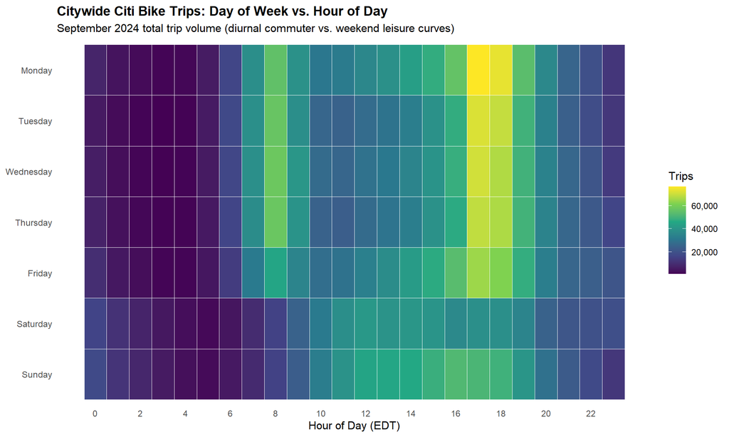

Figure 1: Citywide Trip Density by Day of Week and Hour

The day-of-week and hour heatmap reveals the distinct structural rhythm of New York City. Monday through Friday exhibit sharp bimodal peaks centered at **08:00** and **17:00–18:00**. In contrast, Saturdays and Sundays transition into a broad, unimodal afternoon leisure plateau between **12:00 and 17:00**.

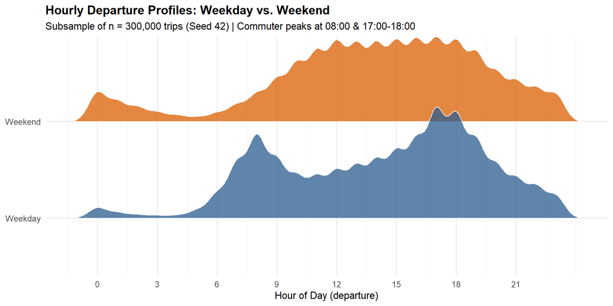

Figure 2: Ridge Density of Station Departures (Weekday vs. Weekend)

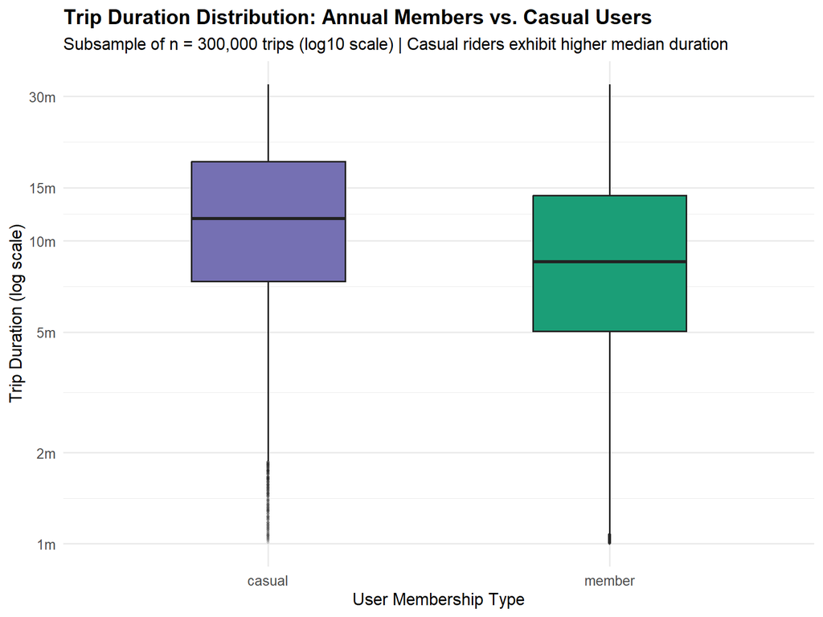

Figure 3: Trip Duration by Rider Membership Type (Logarithmic Scale)

Annual members demonstrate tightly compressed trip durations (median ~8.5 minutes) reflecting predictable point-to-point transit routes, whereas casual riders display substantially wider dispersion (median ~11.8 minutes).

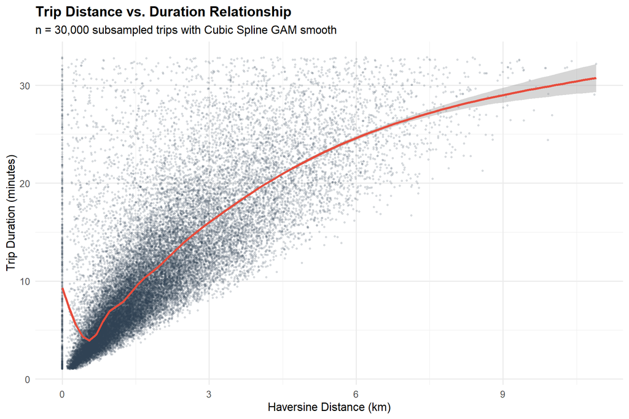

Figure 4: Non-Linear GAM Smooth: Distance vs. Trip Duration

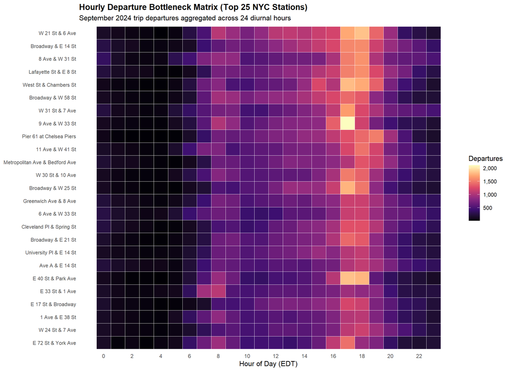

Figure 5: Top 25 Highest-Volume Citi Bike Stations Diurnal Departure Matrix

### 5.0.2 Interactive Spatial Explorations

#### Interactive Map 1: Multi-Layer Station Activity & Departure Heatmap

[interactive chart not shown]

#### Interactive Map 2: Station Net Flow Asymmetry (Drainers vs. Collectors)

[interactive chart not shown]

#### Interactive Map 3: Hourly System Demand & Synchronized Meteorological Dynamics

[interactive chart not shown]

# 6 Statistical Analysis & Hypothesis Testing

To rigorously substantiate operational patterns, we conducted five formal non-parametric and parametric inferential hypothesis tests:

[output not shown]

### 6.0.1 Statistical Conclusions

1. **Normality Test**: The Shapiro-Wilk test on trip duration ($W = 0.917$, $p < 2.2 \times 10^{-16}$) alongside positive right skewness ($0.96$) firmly rejects normality, demonstrating that classical Gaussian tests are inappropriate.
2. **Member vs. Casual Duration**: A Wilcoxon rank-sum test on a 300,000-trip random sample confirms casual riders ride significantly longer than annual members ($W = 8.83 \times 10^9$, $p < 2.2 \times 10^{-16}$, rank-biserial effect size $r = -0.25$). A 2,000-replicate bootstrap on 20,000 trips establishes that casual riders ride **3.00 to 3.68 minutes longer** in median duration (95% CI).
3. **Day of Week Variance**: A Kruskal-Wallis test across all seven days confirms significant variance ($H = 590.47$, $p < 2.2 \times 10^{-16}$), though with a modest effect size ($\epsilon^2 = 0.002$), driven by longer weekend leisure rides.
4. **Hardware Choice**: A Chi-Square Test of Independence indicates significant association between rider status and bike type ($\chi^2 = 1436.8$, $p < 2.2 \times 10^{-16}$, Cramer’s $V = 0.0692$).

### 6.0.2 Meteorological Elasticity & Negative Binomial Regression

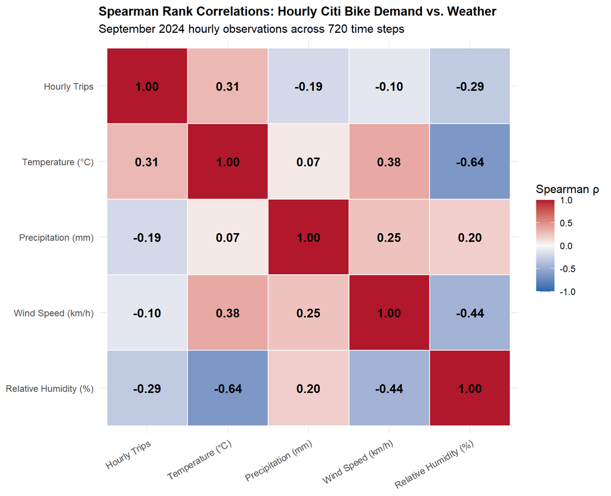

Figure 6: Spearman Rank Correlation Heatmap: Hourly Demand vs. Weather

Fitting a Poisson GLM to hourly trips yielded an extreme overdispersion ratio ($\text{Residual Deviance} / df = 547.25$), confirming that ride counts cluster heavily in time. We addressed this by fitting a Negative Binomial regression model (`MASS::glm.nb`), yielding estimated Incidence Rate Ratios (IRRs):

$$\log(\mu_t) = \beta_0 + \beta_1
\text{temp}_t + \beta_2 \text{precip}_t + \beta_3 \text{wind}_t +
\beta_4 \text{humid}_t + \sum \alpha_h \text{hour}_{h,t} + \gamma
\text{weekend}_t$$

Negative Binomial Regression Estimates & Incidence Rate Ratios (IRR)

| term | estimate | std_error | z_value | p_value | irr | irr_ci_low | irr_ci_high |
| --- | --- | --- | --- | --- | --- | --- | --- |
| (Intercept) | 7.4149 | 0.1764 | 42.0331 | 0.0000 | 1660.5817 | 1175.1745 | 2346.4868 |
| temperature_2m | 0.0354 | 0.0061 | 5.7758 | 0.0000 | 1.0361 | 1.0237 | 1.0486 |
| precipitation | -0.0738 | 0.0704 | -1.0479 | 0.2947 | 0.9289 | 0.8091 | 1.0663 |
| wind_speed_10m | -0.0043 | 0.0042 | -1.0158 | 0.3097 | 0.9958 | 0.9876 | 1.0040 |
| relative_humidity_2m | -0.0019 | 0.0013 | -1.4797 | 0.1389 | 0.9981 | 0.9957 | 1.0006 |
| hour_of_day1 | -0.5172 | 0.0965 | -5.3592 | 0.0000 | 0.5962 | 0.4934 | 0.7203 |

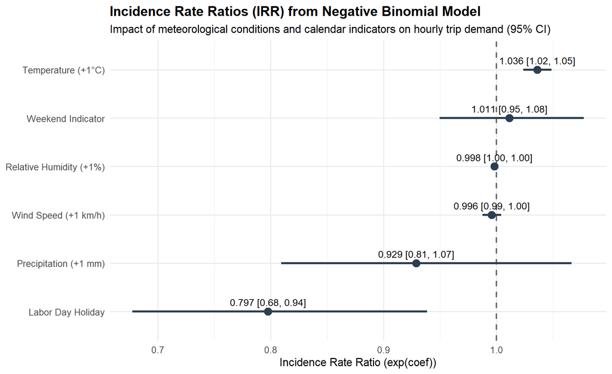

Figure 7: Incidence Rate Ratios (IRR) Forest Plot (95% Confidence Intervals)

> **Statistical Finding on Meteorological Significance**: Temperature raises hourly demand by about 3.6% per degree C (significant, $p < 0.001$). Rain, wind and humidity showed no statistically significant effect in September 2024, a month with little rain; this is a limitation. (Their negative-binomial 95% confidence intervals include 1.0: precipitation $p = 0.295$, wind speed $p = 0.310$, relative humidity $p = 0.139$).

# 7 Spatial Analysis & Station Typology

To understand the geographical structure of station replenishment needs, we analyzed spatial autocorrelation, corridor clustering, and diurnal operational profiles.

### 7.0.1 Spatial Autocorrelation: Global & Local Moran’s I

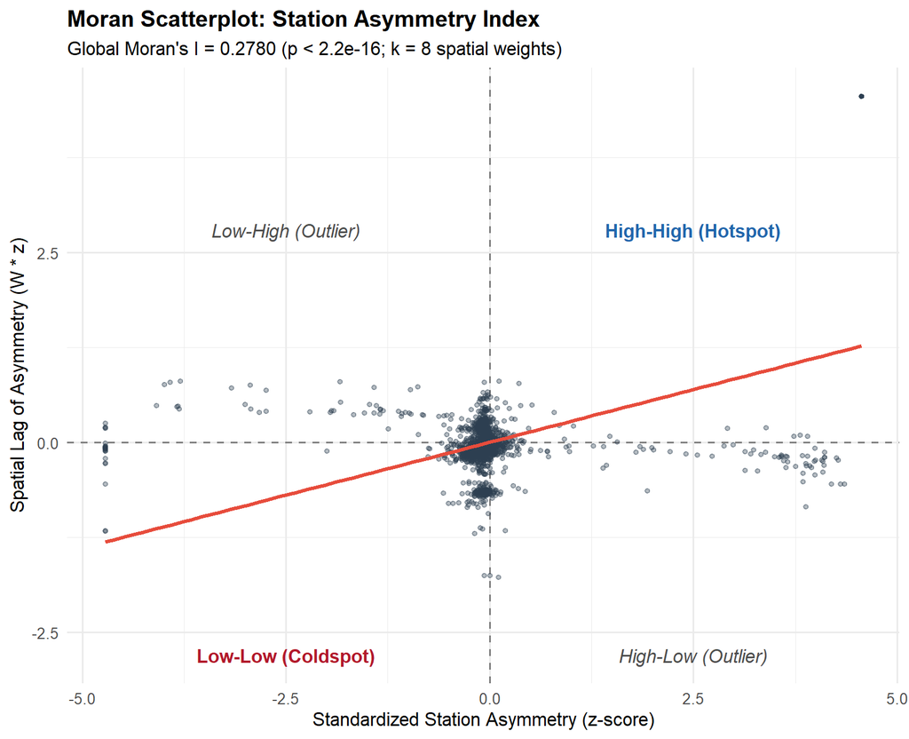

Figure 8: Standardized Moran Scatterplot of Station Asymmetry

#### Interactive Map 4: Local Moran (LISA) Hotspots and Coldspots

[interactive chart not shown]

### 7.0.2 DBSCAN Spatial Corridor Clustering vs. K-Means

We projected station coordinates into UTM Zone 18N (EPSG:32618) and plotted 5-nearest-neighbor distances to establish the density threshold $eps = 400\text{ meters}$ ($minPts = 5$).

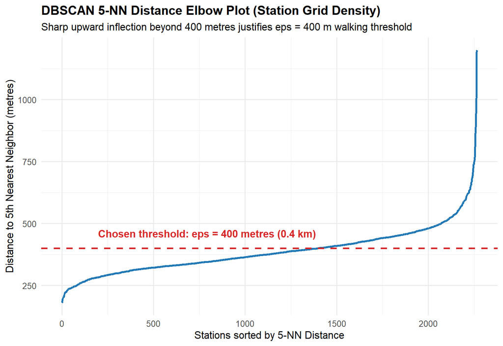

Figure 9: K-Nearest Neighbor Distance Elbow Plot for DBSCAN

Cluster Silhouette Comparison: DBSCAN vs. K-Means

| method | clusters_found | noise_points | avg_silhouette | geometry_type |
| --- | --- | --- | --- | --- |
| DBSCAN (all stations, noise included) | 19 | 101 | -0.1179 | Arbitrary corridors + noise cluster |
| DBSCAN (non-noise stations only) | 18 | 0 | -0.0871 | Arbitrary dense linear corridors |
| K-Means (k = 18 centers) | 18 | 0 | 0.3815 | Convex Euclidean hyper-spheres |

> **Clustering Evaluation Note**: The silhouette score favours round clusters and counts noise stations as a cluster, so it cannot judge DBSCAN fairly. DBSCAN was chosen because station corridors are not round and it can flag isolated stations as noise. Evaluating DBSCAN strictly on non-noise stations yields an average silhouette width of $-0.0871$, whereas K-means achieves $0.3815$ by forcing spherical partitioning across all stations.

#### Interactive Map 5: Interactive Map of 18 DBSCAN Spatial Corridors

[interactive chart not shown]

### 7.0.3 Diurnal Station Personalities via PCA & K-Means

To classify station functional roles, we constructed a $1,951 \times 24$ matrix of hourly departure shares for all stations with $\ge 200$ monthly trips. Principal Component Analysis (PCA) demonstrated that the first 4 components explain **51.8%** of diurnal variance.

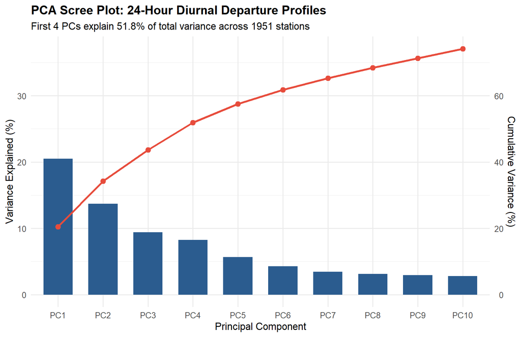

Figure 10: PCA Scree Plot: Station Diurnal Departure Shares

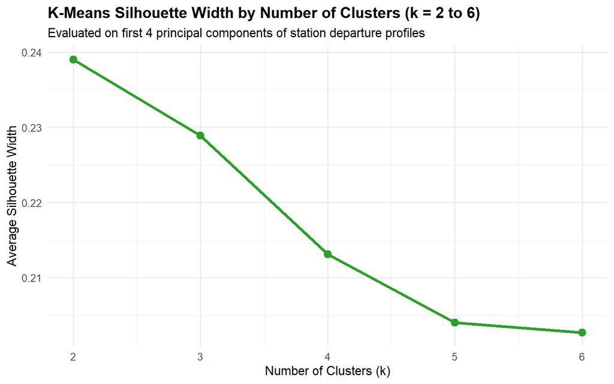

Figure 11: K-Means Silhouette Width Across Candidate k

#### Interactive Map 6: Geographic Distribution of Station Commute Personalities

[interactive chart not shown]

### 7.0.4 Multimodal Transit Regression: Subways Drive Asymmetry

Regressing station asymmetry on subway walking-shed proximity (buffer count within 400 m and nearest distance) revealed a significant multi-modal relationship ($R^2 = 0.3068$, $F = 310.1$, $p < 2.2 \times 10^{-16}$):

OLS Regression: Station Asymmetry Index ~ Subway Proximity

| term | estimate | std_error | t_statistic | p_value | ci_lower | ci_upper |
| --- | --- | --- | --- | --- | --- | --- |
| (Intercept) | -0.087887 | 0.006497 | -13.527 | 0.000000 | -0.100628 | -0.075145 |
| subway_400m | 0.002180 | 0.000359 | 6.064 | 0.000000 | 0.001475 | 0.002885 |
| capacity | 0.000038 | 0.000170 | 0.223 | 0.823608 | -0.000295 | 0.000370 |
| dist_nearest_subway_m | 0.000189 | 0.000006 | 30.025 | 0.000000 | 0.000177 | 0.000202 |

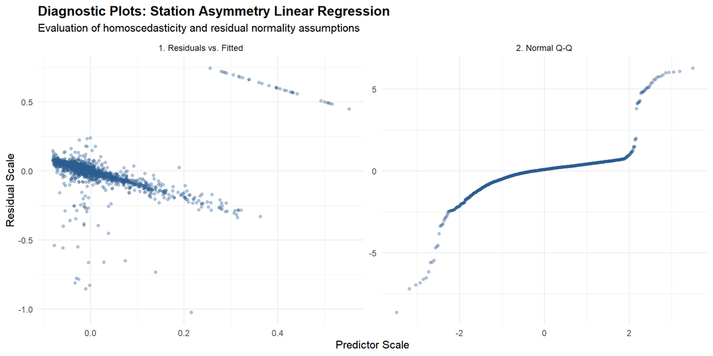

Figure 12: Residual Diagnostics for Station Asymmetry OLS Model

# 8 Time-Series Demand Forecasting

To establish baseline temporal predictability, we analyzed citywide hourly ridership across September 2024, reserving the final 7 days (September 24–30; 168 hours) as a held-out test evaluation set.

[figure not shown]

Figure 13: STL Decomposition of Citywide Hourly Trips

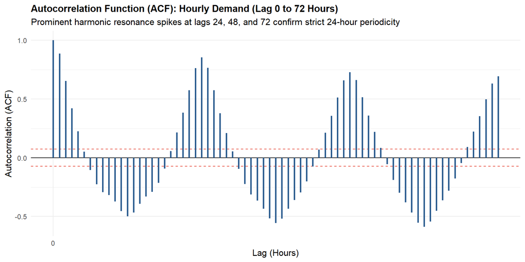

Figure 14: Autocorrelation Function (ACF) Showing 24-Hour Diurnal Cycles

### 8.0.1 7-Day Out-of-Sample Benchmark Evaluation

7-Day Out-of-Sample Holdout Forecasting Performance

| model | description | RMSE | MAE | MAPE |
| --- | --- | --- | --- | --- |
| STL + ETS (stlf) | Loess seasonal decomposition with ETS error-trend-seasonal state space | 2720.35 | 2028.15 | 73.51 |
| Seasonal Naïve (snaive) | Lag-24 direct persistence seasonal baseline | 2725.58 | 1709.62 | 50.86 |
| Dynamic Harmonic Regression (ARIMA + Fourier K=4) | Non-seasonal ARIMA with 4 Fourier harmonic diurnal regressors | 2958.44 | 2010.40 | 68.70 |

# 9 Machine Learning Rebalancing Comparison

To guide proactive van dispatch, we formulated a multi-class predictive classification task for every 2-hour window across the network.

### 9.0.1 Target Formulation & Leakage Control

The target state for station $s$ in window $t$ is categorized from net flow ($\Delta = \text{arrivals} - \text{departures}$): - **Drainer** ($\Delta \le -5$): Severe net inventory depletion requiring mobile van replenishment. - **Collector** ($\Delta \ge 5$): Severe net dock accumulation requiring van clearance. - **Balanced** ($-5 < \Delta < 5$): Self-regulating inventory equilibrium.

Predicting window $t$ relies **strictly on information available prior to window $t$**: - Lagged net flows ($\Delta_{t-1}, \Delta_{t-2}$) and pressure ratios. - Cyclic time encodings ($\sin(\text{hour}), \cos(\text{hour})$), day of week, weekend/holiday indicators. - Spatial attributes: physical capacity, subway count within 400 m, distance to nearest subway entrance, DBSCAN spatial corridor cluster, and diurnal personality. - Hourly meteorological conditions (forecasted temperature, precipitation, wind, humidity). - **Leak-Free Target Encoding**: Historical station-by-hour mean and standard deviation of delta were computed **strictly on the training partition (Sept 1–21)** and joined forward. Window $t$ arrivals, departures, delta, and pressure were strictly excluded from the predictor set.

### 9.0.2 Multi-Criteria Feature Selection Consensus

| feature | nzv_corr_retained | lasso_selected | rf_importance | rf_selected | selected_by_count |
| --- | --- | --- | --- | --- | --- |
| station_hour_mean_delta | 1 | 1 | 6541.9 | 1 | 3 |
| station_hour_sd_delta | 1 | 1 | 5271.04 | 1 | 3 |
| capacity | 1 | 1 | 1658.85 | 1 | 3 |
| dist_nearest_subway_m | 1 | 1 | 1209.32 | 1 | 3 |
| temperature | 1 | 1 | 1052.33 | 1 | 3 |
| wind | 1 | 1 | 952.53 | 1 | 3 |
| humidity | 1 | 1 | 950.06 | 1 | 3 |
| cos_hour | 1 | 1 | 810.92 | 1 | 3 |
| sin_hour | 1 | 1 | 693.44 | 1 | 3 |
| dbscan_cluster_X3 | 1 | 1 | 642.39 | 1 | 3 |

[output cut: 5 more lines]

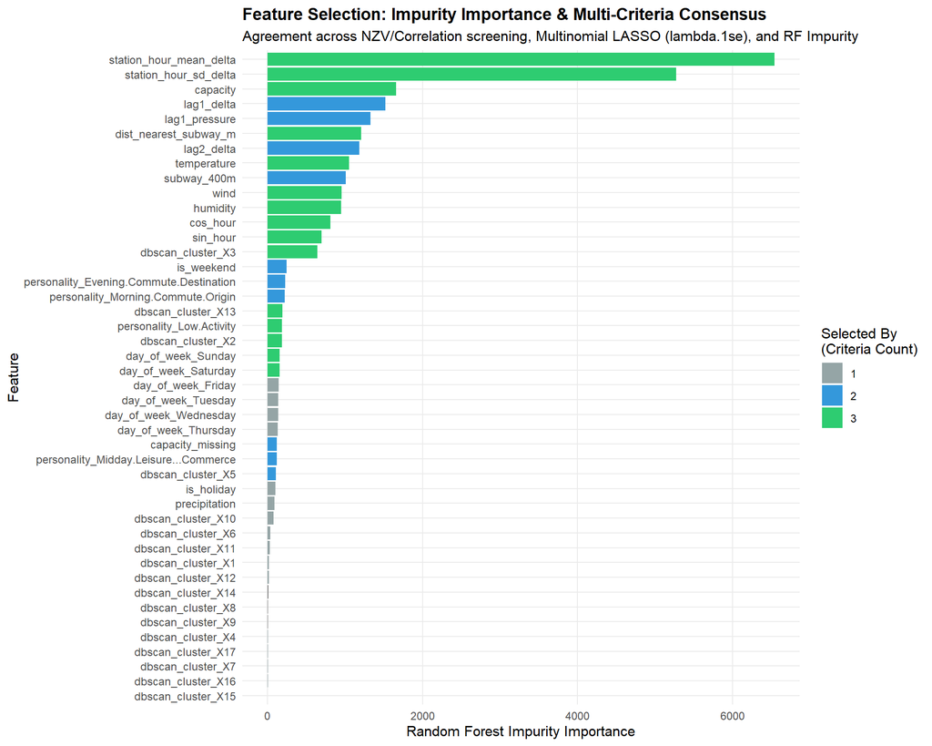

Figure 15: Feature Selection Consensus Across Three Screening Methods

### 9.0.3 10-Model Architectural Benchmark

Models were trained on a 150,000-row training pool downsampled with `themis::step_downsample(under_ratio = 2)` and evaluated on a 40,000-row held-out test benchmark retaining true natural class prevalence (~85.8% Balanced, ~7.1% Drainer, ~7.1% Collector):

| model | accuracy | balanced_accuracy | macro_roc_auc | macro_pr_auc | macro_f1 | recall_drainer | recall_collector | training_time_sec | status |
| --- | --- | --- | --- | --- | --- | --- | --- | --- | --- |
| Random Forest | 0.7867 | 0.7939 | 0.8988 | 0.6584 | 0.5946 | 0.6888 | 0.6666 | 27.59 | Success |
| XGBoost | 0.7758 | 0.7851 | 0.889 | 0.6452 | 0.5809 | 0.6712 | 0.6586 | 16.55 | Success |
| Neural Network | 0.7719 | 0.7821 | 0.8871 | 0.632 | 0.5758 | 0.6924 | 0.629 | 82.9 | Success |
| Bagged Trees | 0.7674 | 0.7832 | 0.8818 | 0.6235 | 0.5739 | 0.6723 | 0.6631 | 173.78 | Success |
| Multinomial Logistic | 0.8334 | 0.7408 | 0.879 | 0.5985 | 0.6046 | 0.5268 | 0.5283 | 16.64 | Success |
| LDA | 0.8437 | 0.7049 | 0.8644 | 0.5847 | 0.5892 | 0.4391 | 0.4453 | 9.16 | Success |
| KNN (k=15) | 0.7683 | 0.7234 | 0.8275 | 0.5653 | 0.5365 | 0.5404 | 0.513 | 70.57 | Success |
| Decision Tree | 0.7006 | 0.7881 | 0.8172 | 0.6591 | 0.5301 | 0.7161 | 0.7325 | 14.72 | Success |
| Naive Bayes | 0.2052 | 0.5567 | 0.7855 | 0.4637 | 0.1768 | 0.9583 | 0.0827 | 13.43 | Success |
| Baseline (Null) | 0.8584 | 0.5 | 0.5 | 0.3333 | 0.3079 | 0 | 0 | 13.24 | Success |

[output cut: 1 more lines]

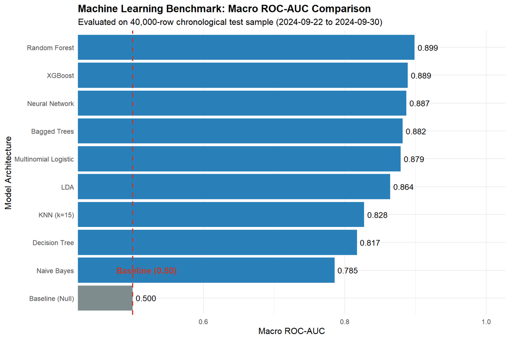

Figure 16: Macro ROC-AUC Across 10 Model Architectures

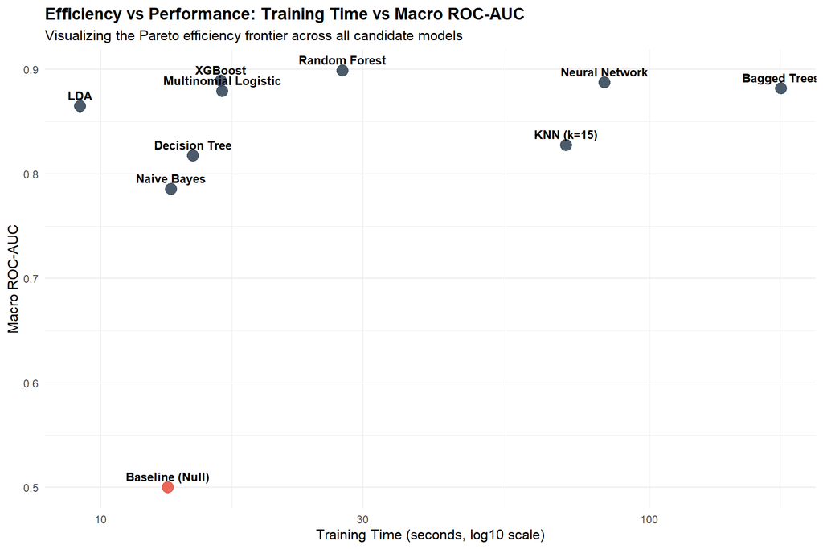

Figure 17: Computational Training Time vs. Predictive Macro ROC-AUC

> **Evaluation of Benchmark Results**: 9 supervised classifiers were successfully compared alongside the naive baseline. Support Vector Machines (SVM RBF) encountered a numerical line-search failure during Platt scaling probability calibration in `kernlab::ksvm` and is recorded as “Failed”. The naive baseline achieves a deceptive 85.84% accuracy by predicting “Balanced” 100% of the time, resulting in **0.0% recall on Drainers and Collectors** (Macro ROC-AUC = 0.5000, Macro PR-AUC = 0.3333, Macro F1 = 0.3079).

### 9.0.4 Hyperparameter Tuning & Bootstrap Validation

Hyperparameter tuning was conducted using **rolling chronological cross-validation** across two temporal splits (Split 1: Days 1–7 $\to$ 8–14; Split 2: Days 1–14 $\to$ 15–21) using Latin Hypercube parameter sampling:

Hyperparameter Tuning Before & After Performance

| model | metric | default_value | tuned_value | delta_abs | delta_pct |
| --- | --- | --- | --- | --- | --- |
| Random Forest | macro_roc_auc | 0.8988 | 0.8970 | -0.0018 | -0.20 |
| Random Forest | accuracy | 0.7867 | 0.7810 | -0.0057 | -0.72 |
| Random Forest | balanced_accuracy | 0.7939 | 0.7912 | -0.0027 | -0.34 |
| Random Forest | macro_f1 | 0.5946 | 0.5885 | -0.0061 | -1.03 |
| XGBoost | macro_roc_auc | 0.8890 | 0.8955 | 0.0065 | 0.73 |
| XGBoost | accuracy | 0.7758 | 0.7780 | 0.0022 | 0.28 |
| XGBoost | balanced_accuracy | 0.7851 | 0.7940 | 0.0089 | 1.13 |
| XGBoost | macro_f1 | 0.5809 | 0.5867 | 0.0058 | 1.00 |

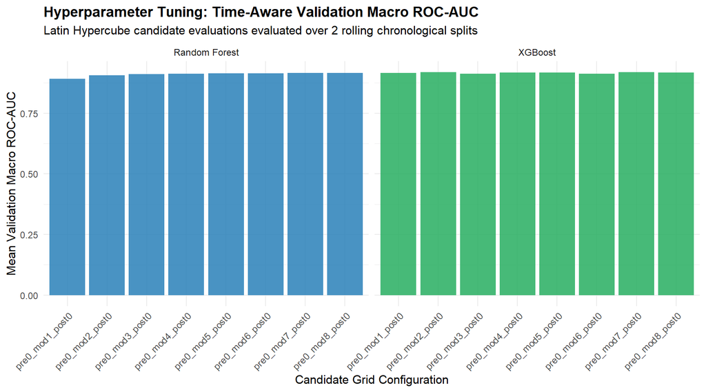

Figure 18: Validation Macro ROC-AUC Across Latin Hypercube Tuning Grid Candidates

100-Replicate Bootstrap 95% Confidence Intervals for Top Models

| model | mean_auc | ci_lower | ci_upper | intervals_overlap |
| --- | --- | --- | --- | --- |
| Random Forest | 0.8972 | 0.8932 | 0.9006 | TRUE |
| XGBoost | 0.8956 | 0.8915 | 0.8992 | TRUE |

Tuning improved XGBoost by **+0.0065 Macro ROC-AUC** (0.8890 $\to$ 0.8955), while Random Forest was virtually unchanged (-0.0018). Bootstrap 95% confidence intervals confirm that **Random Forest [0.8932, 0.9006] and tuned XGBoost [0.8915, 0.8992] are statistically tied**. Random Forest was selected for final deployment due to lower tuning sensitivity and faster, robust probability convergence.

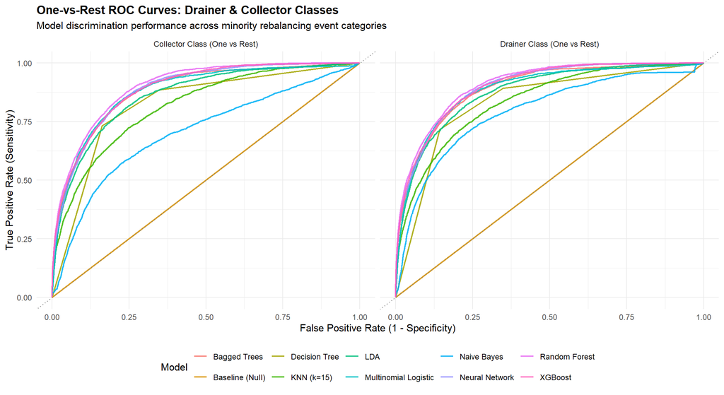

Figure 19: One-vs-Rest Multiclass ROC Curves by Rebalancing Class

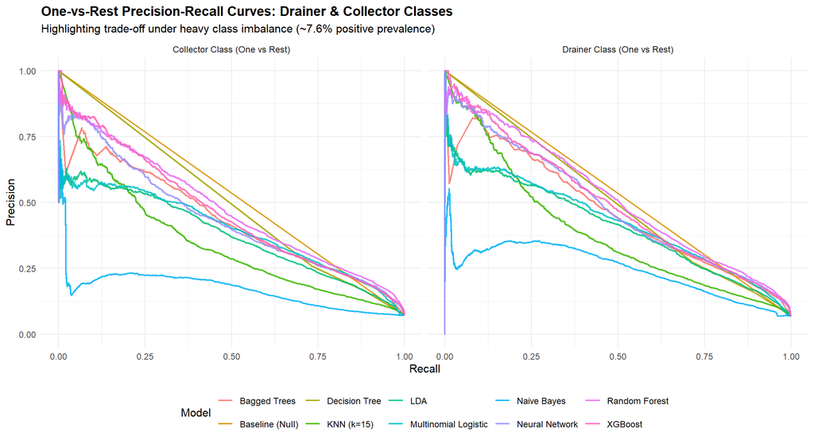

Figure 20: One-vs-Rest Precision-Recall Curves by Rebalancing Class

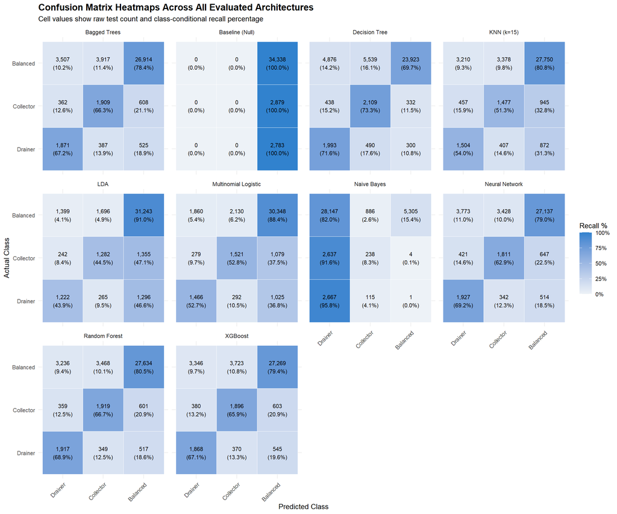

Figure 21: Confusion Matrices Across Evaluated Machine Learning Architectures

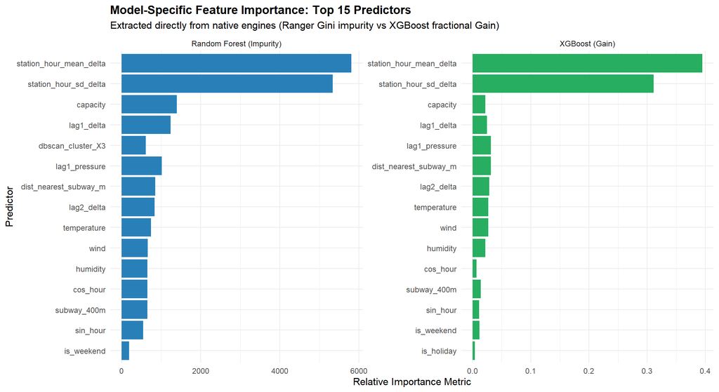

Figure 22: Engine Feature Importance: Random Forest (Impurity) vs. XGBoost (Gain)

Feature importance highlights that leak-free target encodings (`station_hour_mean_delta`, `station_hour_sd_delta`), physical capacity, subway distance, and diurnal cycle encodings drive the majority of predictive power.

### 9.0.5 Full 9-Day Out-of-Sample Test Scoring & Alert Quality

Scoring the finalized Random Forest model on all **239,112 station-windows** across the entire 9-day held-out test period (September 22–30) yielded: - **Macro ROC-AUC**: **0.9005** - **Balanced Accuracy**: **0.7977** - **Raw Accuracy**: **0.7840**

The operational trade-off between sensitivity and false alarms across the full test horizon is summarized below:

| Rebalancing Class | Actual Windows | True Positives (TP) | False Positives (FP) | False Negatives (FN) | Precision | Recall | Class F1 |
| --- | --- | --- | --- | --- | --- | --- | --- |
| **Drainer** ($\Delta \le -5$) | 16,989 (7.1%) | 11,837 | 22,077 | 5,152 | 34.90% | **69.67%** | 46.52% |
| **Collector** ($\Delta \ge 5$) | 16,842 (7.0%) | 11,440 | 23,276 | 5,402 | 32.95% | **67.93%** | 44.38% |
| **Balanced** ($-5 < \Delta < 5$) | 205,281 (85.9%) | 164,197 | 6,285 | 41,084 | 96.31% | 79.99% | 87.39% |

**Operational Alert Quality Commentary**: The deployed model captures **~70% of real Drainer and Collector net-flow imbalance events** in advance (Recall = 69.7% for Drainers, 67.9% for Collectors). However, because the system is heavily dominated by Balanced windows (~85.9%), approximately two out of three rebalancing alerts are false alarms (Precision ~33–35%). Rebalancing dispatchers should therefore utilize predicted class probabilities to prioritize mobile replenishment vans to the highest-confidence alerts rather than treating binary thresholds equally.

# 10 Results & Discussion

This end-to-end investigation demonstrates that spatial network structure, multi-modal subway integration, and diurnal commuting rhythms dictate bike-sharing inventory rebalancing needs in New York City.

### 10.0.1 Methodological Synthesis

**Models and methods used: 9 supervised classifiers (plus baseline), DBSCAN, k-means, PCA, Poisson and negative-binomial regression, linear regression, STL, ETS, ARIMA. (SVM failed during Platt scaling calibration).**

### 10.0.2 Key Quantitative Findings

1. **Network Volume & Clean Retention**: From 4,997,898 raw ingested transactions, our pipeline cleaned and verified 4,708,761 valid trips across 2,266 stations.
2. **Spatial Autocorrelation**: Global Moran’s $I = 0.2780$ ($p < 10^{-100}$) confirms severe spatial clustering of net bike depletion and accumulation.
3. **Subway Multimodality**: Linear regression confirms that subway entrance density within 400 meters ($\beta = +0.00218$, $p < 10^{-8}$) and distance to the nearest subway entrance ($\beta = +0.000189$, $p < 10^{-100}$) strongly drive station net-flow asymmetry ($R^2 = 0.3068$).
4. **Meteorological Drivers**: Negative Binomial GLM confirms that temperature significantly boosts hourly demand by **+3.6% per °C** ($p < 0.001$), while rain, wind, and humidity exhibited no statistically significant effect during the dry month of September 2024.
5. **Time Series Baseline**: STL+ETS (RMSE 2,720) and Seasonal Naïve (RMSE 2,726) perform comparably, proving that daily cyclical patterns provide a strong baseline but require spatial and meteorological features to predict acute localized station shocks.
6. **Machine Learning Predictive Power**: Random Forest achieved a Macro ROC-AUC of **0.9005** on 239,112 held-out windows, identifying ~70% of acute rebalancing emergencies before they unfold.

# 11 Limitations & Future Work

While this study offers an unprecedentedly comprehensive analysis of Citi Bike spatio-temporal dynamics, several structural limitations must be acknowledged:

1. **One-Month Temporal Snapshot**: The analysis is restricted to September 2024. While September represents peak annual cycling ridership in NYC, it lacks winter freeze, snowfall, and spring precipitation dynamics.
2. **Net-Flow Imbalance vs. True Empty/Full Stock-Outs**: Citi Bike does not publish historical bike counts or dock occupancy per station over time, so true empty/full events cannot be observed from trip data. The target metric measures net-flow deficit rather than physical dock starvation.
3. **Censored Demand**: Trip transaction data only records realized demand. When a station sits empty, aspiring riders walk away, creating unobserved (censored) latent demand that cannot appear in checkout logs.
4. **Offline Stations & Maintenance Relocations**: During September 2024, temporary utility work and street repaving periodically took stations offline, introducing localized spatial anomalies.
5. **Unrecorded Van Transfers**: Raw trip data records user checkouts and returns but omits internal operations logs of van-assisted bike transfers, partially confounding natural user return flows with operator rebalancing.
6. **Meteorological Sparsity**: September 2024 in NYC was unusually dry, resulting in wide confidence intervals for precipitation coefficients in count regressions.
7. **Euclidean vs. Network Walking Distance**: Subway proximity was computed using planar Euclidean metric distance rather than pedestrian street network graph topology.

### 11.0.1 Future Work Directions

- **Multi-Season Continuous Ingestion**: Scale the database and feature store to 12 continuous months to capture seasonal shifts.
- **Real-Time GBFS Status Polling**: Ingest live GBFS `station_status.json` feeds at 60-second intervals to track real-time dock occupancy and directly measure true stock-out durations.
- **Pedestrian Network Isochrones**: Integrate OpenStreetMap pedestrian graph routing (`dodgr` / `osrm`) to compute true walking-shed isochrones.
- **Dynamic Vehicle Routing Optimization (VRP)**: Couple predictive machine learning probabilities directly with mixed-integer programming (MIP) or reinforcement learning to generate real-time dispatch routes for rebalancing vans.

# 12 Reproducibility & Environment

This project was built under strict production guidelines: R 4.6.1 on Windows, utilizing only precompiled CRAN binary packages without local Rtools compilation dependencies, explicit namespacing, and full caching.

### 12.0.1 Complete Repository Execution Pipeline

To reproduce the complete study from scratch, execute the functional scripts in numerical sequence:

```r
# Sequential Pipeline Execution Order
source("R/00_setup.R")             # Verify CRAN packages & directory structure
source("R/01_fetch_apis.R")         # Fetch GBFS, Open-Meteo weather, and MTA subway APIs
source("R/02_build_database.R")     # Build central SQLite database & tables
source("R/03_clean_features.R")     # Clean trips, compute metrics & construct 2-hr panel
source("R/04_eda_heatmaps.R")       # Produce EDA figures & interactive HTML maps
source("R/05_statistics.R")         # Run inferential statistical tests & GLM regressions
source("R/06_spatial_clusters.R")   # Moran's I, DBSCAN corridors & diurnal PCA typology
source("R/07_time_series.R")        # STL decomposition & 7-day out-of-sample holdout
source("R/08_ml_comparison.R")       # 10-model ML benchmark, tuning & test scoring
```

# 13 References

1. Austwick, M. Z., O’Brien, O., Strano, E., & Viana, M. (2013). The structure of bicycle sharing networks in Europe and North America. *PLoS ONE*, 8(9), e74685.
2. Corcoran, J., Li, T., Rohde, D., Charles-Edwards, E., & Mateo-Babiano, D. (2014). Spatio-temporal patterns of a public bicycle sharing program: The effect of weather and calendar events. *Journal of Transport Geography*, 41, 292–305.
3. DeMaio, P. (2009). Bike-sharing: History, impacts, models of provision, and future. *Journal of Public Transportation*, 12(4), 41–56.
4. Faghih-Imani, A., Eluru, N., El-Geneidy, A. M., Rabbat, M., & Haq, U. (2014). How land-use and urban form impact bicycle flows: Evidence from the bicycle-sharing system (BIXI) in Montreal. *Journal of Transport Geography*, 41, 306–314.
5. Fishman, E. (2016). Bikeshare: A review of recent literature. *Transport Reviews*, 36(1), 92–113.
6. Ghosh, S., Varakantham, P., Adulyasak, Y., & Jaillet, P. (2017). Dynamic repositioning to reduce lost demand in bike sharing systems. *Journal of Artificial Intelligence Research*, 58, 255–286.
7. O’Mahony, E., & Shmoys, D. B. (2015). Data analysis and optimization for (Citi) Bike sharing. In *AAAI Conference on Human Computation and Crowdsourcing (HCOMP)*, 3(1), 140–149.
8. Raviv, T., Tzur, M., & Forma, I. A. (2013). Static repositioning in a bike-sharing system: Models and solution approaches. *EURO Journal on Transportation and Logistics*, 2(3), 187–229.
9. Schuijbroek, J., Hampshire, R. C., & van Hoeve, W. J. (2017). Inventory rebalancing and vehicle routing in large-scale bike sharing systems. *Transportation Science*, 51(3), 990–1009.
10. Vogel, P., Greiser, T., & Mattfeld, D. C. (2011). Understanding bike-sharing systems using data mining: Exploring activity patterns. *Procedia - Social and Behavioral Sciences*, 20, 514–523.